# **CIV1299: Construction Safety: IoT and AI Solutions**

# **Lab 1: Artificial Neural Networks (ANNs) -- [100pts]**

### **Google Colab Link**

Click on the "Share" button in the top-right corner of the Colab interface. This will open a sharing dialog. In the sharing dialog, adjust the sharing settings by choosing `Anyone with the link` so that Anyone who has the link can access the notebook. Copy and paste the Shared Link here:

Shared link:

https://drive.google.com/file/d/1VN9enfcTGJ820AjnzvHihc2WuYzJbbbI/view?usp=sharing

### **Submission Guidelines**

- Submit an HTML file containing all your code, outputs, and answers. You can produce a HTML file directly from Google Colab. The Colab instructions are provided at the end of this document.
- If you encounter difficulties submitting the HTML file, please create a PDF document that includes all your code, results, and explanatory notes. You can generate a PDF from your Google Colab file by navigating to `File` -> `Print` and then selecting `Save as PDF`. Keep in mind that **the preferred method of submission is the HTML file, and submitting a PDF will lead into a 5% deduction of the total grade of this lab assignment.**
- We strongly recommend utilizing Google Colab for this assignment. If you choose to use Jupyter Notebook, kindly complete your work and upload the Jupyter Notebook file to Google Colab before submitting.
- Please thoroughly review your final submission to ensure that your answers are fully visible and not truncated at the margins.
- Remember to provide a link to your Google Colab notebook within your submission.

### **Note:**

This notebook will walk you through many of the important features of PyTorch that you will need to use throughout the semester. In some cells you will see code blocks that look like this:

```
# =================== YOUR CODE STARTS HERE ==================

# ==================== YOUR CODE ENDS HERE ===================
```

You should replace the `pass` statement with your own code and leave the blocks intact, like this:

```
# =================== YOUR CODE STARTS HERE ==================
y = m * x + b
# ==================== YOUR CODE ENDS HERE ===================
```

When completing the notebook, please adhere to the following rules:

- Do not write your code or modify any code outside of code blocks.
- Run all cells before submitting. You will only get credit for code that has been run.

# **Part 1: Training an ANN**

The sample code provided below is a single-layer ANN trained on the [MNIST dataset](https://en.wikipedia.org/wiki/MNIST_database) to identify digits less than 3 or greater than and equal to 3. Modify the code by changing any of the following and observe how the accuracy and error are affected:

- number of training iterations
- number of hidden units
- numbers of layers
- types of activation functions
- learning rate

Please select at least three different options from the list above. For each option, please select two to three different parameters and provide a table.

```python
import torch
import torch.nn as nn
import torch.nn.functional as F
from torchvision import datasets, transforms
import matplotlib.pyplot as plt # for plotting
import torch.optim as optim
from tqdm import tqdm  # Importing tqdm for progress bars during training
torch.manual_seed(1) # set the random seed
```

```
<torch._C.Generator at 0x7f5a9c361310>
```

Here is a schematic figure of the architecture of a single-layer ANN:

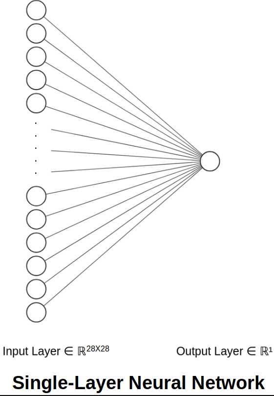

Let's try to implement this model:

### Question 1.1 -- [2pt]

Please fill in the blank.

```python
# Build a Single-layer Neural Network
class Pigeon(nn.Module):
    def __init__(self):
        super(Pigeon, self).__init__()
        # =================== YOUR CODE STARTS HERE ==================
        self.fc = nn.Linear( 784  , 1  ) # Fill in the number of input and output nodes (Hint: Input image sizes are 28 X 28.
        # 28 * 28 = 784 input features
        # 1 for binary classification (greater or less than digit 3)
        # ==================== YOUR CODE ENDS HERE ===================

    def forward(self, x):
        x = x.view(x.size(0), -1)
        x = self.fc(x)
        return x

pigeon = Pigeon()
```

### Question 1.2 -- [9X2pt]

The above box has 9 lines of codes. Explain what each line is doing. -- (Each line 2pt)

Please note that you do not have to provide any code here in this question. A brief textual explanation is absolutely sufficient.

`class Pigeon(nn.Module):`

```python
# =================== YOUR ANSWER STARTS HERE ==================

'''
class Pigeon(nn.Module):: This line is defining a new class named Pigeon that
inherits from nn.Module, indicating that it is a PyTorch neural network module.

'''

# ==================== YOUR ANSWER ENDS HERE ===================
```

`def __init__(self):`

```python
# =================== YOUR ANSWER STARTS HERE ==================

'''
__init__ is a special function in python used for constructing instances of
classes.

def __init__(self): This line defines the constructor method __init__ for the
Pigeon class. It initializes the object when an instance is created and is
commonly used to set up attributes and parameters, such as defining the
neural network architecture in this case.


'''

# ==================== YOUR ANSWER ENDS HERE ===================
```

`super(Pigeon, self).__init__()`

```python
# =================== YOUR ANSWER STARTS HERE ==================

'''
The super() function is used to give access to methods and properties of a
parent or sibling class.

The line super(Pigeon, self).__init__() invokes the constructor of the parent
class (nn.Module). This is done to inherit and execute the initialization
procedures defined in the parent class. It ensures that the Pigeon class is
correctly initialized and benefits from any setup or attributes provided by
its parent class.


'''

# ==================== YOUR ANSWER ENDS HERE ===================
```

`self.fc = nn.Linear(28 * 28, 1)`

```python
# =================== YOUR ANSWER STARTS HERE ==================
'''
Here we are creating a fully connected layer.

- nn.Linear: Represents a fully connected layer in PyTorch.

- (28 * 28, 1): Specifies 28 * 28 input features and 1 output feature
for the linear layer.

- Common for processing 28x28 pixel images in binary classification tasks.
- The layer is designed to produce a single output, often used for probability
prediction in binary classification (similar to our case).

'''

# ==================== YOUR ANSWER ENDS HERE ===================
```

`def forward(self, x):`

```python
# =================== YOUR ANSWER STARTS HERE ==================

'''


The line def forward(self, x): in a PyTorch neural network class marks the
beginning of the forward method, which defines how the input data x is
processed during the forward pass through the neural network.

- def forward(self, x):: Declares the forward method, a part of PyTorch models.
- self: Refers to the instance of the class (Pigeon) itself.
- x: Represents the input data that will be processed by the neural network
during the forward pass.


'''

# ==================== YOUR ANSWER ENDS HERE ===================
```

`x = x.view(x.size(0), -1)`

```python
# =================== YOUR ANSWER STARTS HERE ==================

'''
The line x = x.view(x.size(0), -1) in a PyTorch neural network's forward method
is responsible for reshaping or flattening the input tensor x.

- x: Represents the input tensor to the neural network.

- view(x.size(0), -1): Reshapes the input tensor. The first argument
x.size(0) maintains the batch size, and -1 infers the size along the
remaining dimensions.


'''

# ==================== YOUR ANSWER ENDS HERE ===================
```

`x = self.fc(x)`

```python
# =================== YOUR ANSWER STARTS HERE ==================

'''
The line x = self.fc(x) in a PyTorch neural network's forward
method applies thelinear transformation to the input tensor x
using the fully connected layer (fc).

- self.fc: Refers to the fully connected layer defined in the
neural network's constructor.

- x: Represents the input tensor that has been reshaped or processed in
earlier layers.

- x = self.fc(x): Applies the linear transformation to the input tensor,
which involves multiplying the input by weight, adding a bias,
and producing an output.



'''


# ==================== YOUR ANSWER ENDS HERE ===================
```

`return x`

```python
# =================== YOUR ANSWER STARTS HERE ==================

'''

The line return x in a PyTorch neural network's forward method signifies the
end of the forward pass and returns the final output tensor.

- x: Represents the output tensor after passing through the
neural network's layers.

'''

# ==================== YOUR ANSWER ENDS HERE ===================
```

`pigeon = Pigeon()`

```python
# =================== YOUR ANSWER STARTS HERE ==================

'''

The line pigeon = Pigeon() creates an instance of the Pigeon class,
initializing a neural network model.

- Pigeon(): Calls the constructor (__init__) of the Pigeon class,
creating an object (instance) of the class.

- pigeon: Represents the variable name assigned to the created instance
of the Pigeon class.

In simpler terms, this line creates a neural network model named pigeon
based on the architecture defined in the Pigeon class.


'''
# ==================== YOUR ANSWER ENDS HERE ===================
```

```python
# load the data
mnist_data = datasets.MNIST('data', train=True, download=True)
mnist_data = list(mnist_data)
mnist_train = mnist_data[:1000]
mnist_val   = mnist_data[1000:2000]
img_to_tensor = transforms.ToTensor()
```

### Question 1.3 -- [5pt]

Visulize your data! Display 10 images in a 5x2 grid with their labels.

**Hint:** Expected output is:

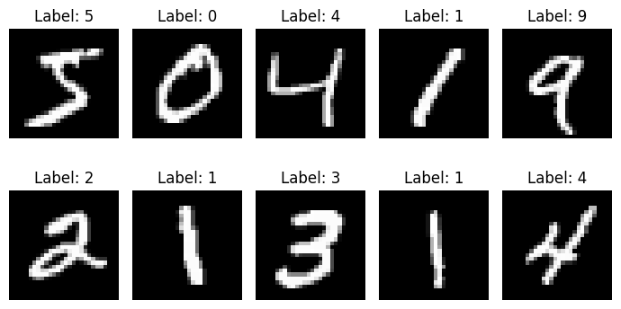

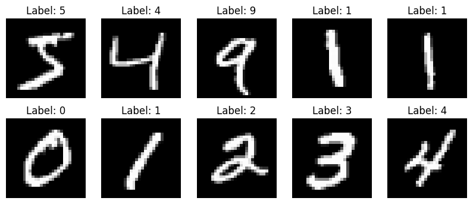

```python
# =================== YOUR CODE STARTS HERE ==================
# Write code to display 10 images in a 5x2 grid

import matplotlib.pyplot as plt


#setting up subplots.

fig, axes = plt.subplots(2, 5, figsize=(10, 4))


for i in range(10):
    image, label = mnist_train[i]
    ax = axes[i % 2, i // 2]
    ax.imshow(image, cmap='gray')
    ax.set_title(f'Label: {label}')
    ax.axis('off')

plt.show()


# ==================== YOUR CODE ENDS HERE ===================
```

```python
# Training settings
criterion = nn.BCEWithLogitsLoss()
optimizer = optim.SGD(pigeon.parameters(), lr=0.005, momentum=0.9)
num_epochs = 20  # Number of training epochs

# Training loop with progress bar
train_losses = []
for epoch in tqdm(range(num_epochs), desc='Training Progress'):
    epoch_loss = 0.0
    for (image, label) in mnist_train:
        actual = torch.tensor(label < 3).reshape([1, 1]).type(torch.FloatTensor)
        out = pigeon(img_to_tensor(image))
        loss = criterion(out, actual)
        loss.backward()
        optimizer.step()
        optimizer.zero_grad()
        epoch_loss += loss.item()
    train_losses.append(epoch_loss / len(mnist_train))
```

### Question 1.4 -- [4X3pt]

Explain the role of the following lines from the above code: (What is exactly happening in each line? What happens if we remove that line? Why is this line necessary?) Please note that you do not have to provide any code in this question. Textual explanation is absolutely sufficient.

`loss = criterion(out, actual)` -- 3pt

```python
# =================== YOUR ANSWER STARTS HERE ==================

'''
Role:
loss = criterion(out, actual) calculates the Binary Cross Entropy with
Logits Loss, quantifying the dissimilarity between the model's predictions
and actual labels.

Removal:
If this line is removed, there would be no measure of model performance for
the optimization process. This would prevent the model from learning and
improving during training.

Necessity:
This line is necessary as the loss guides the backpropagation algorithm,
allowing the model's parameters to be adjusted in the direction that minimizes
the error. It serves as a feedback signal for optimizing the model's
performance on the training data.

'''


# ==================== YOUR ANSWER ENDS HERE ===================
```

`loss.backward()` -- 3pt

```python
# =================== YOUR ANSWER STARTS HERE ==================

'''

Role:
loss.backward() computes the gradients of the model's parameters with respect
to the computed loss.

If Removed:
If this line is removed, the gradients needed for parameter updates would not
be calculated. Backpropagation is a fundamental step for training
neural networks, and without it, the model would not learn from the data,
and parameter updates would not occur.

Necessity:
This line is necessary for training as it enables the optimization algorithm to
adjust the model's parameters based on the computed gradients.
Gradients guide the parameter updates, allowing the model to
iteratively improve its performance on the training data.


'''

# ==================== YOUR ANSWER ENDS HERE ===================
```

`optimizer.step()` -- 3pt

```python
# =================== YOUR ANSWER STARTS HERE ==================

'''

Role:
optimizer.step() updates the model's parameters based on the computed gradients
during backpropagation. It performs a single optimization step, adjusting the
model's weights to reduce the loss.

if Removed:
If this line is removed, the model's parameters would not be updated,
and the learning process would be ineffective. The optimizer's responsibility
is to apply the computed gradients to iteratively improve the model,
and without this step, the model would not learn from the data.

Necessity:
This line is necessary for the training loop to have an impact on the model.
It ensures that the optimization algorithm modifies the model's parameters in a
way that minimizes the loss, aligning the model's predictions with the
ground truth labels.





'''

# ==================== YOUR ANSWER ENDS HERE ===================
```

`optimizer.zero_grad()` -- 3pt

```python
# =================== YOUR ANSWER STARTS HERE ==================

'''
Role:
optimizer.zero_grad() resets the gradients of all the model parameters to zero.
This is necessary because, during backpropagation, PyTorch
accumulates gradients. Zeroing the gradients prevents gradient
accumulation from previous iterations.

if Removed:
If this line is removed, gradients would accumulate across multiple iterations,
leading to incorrect parameter updates. The model would effectively carry the
gradient information from previous batches into the current batch,
potentially hindering convergence and model learning.

Necessity:
This line is necessary to ensure that gradients are fresh for each
batch of data. It prevents unintended interactions between gradients from
different iterations, promoting accurate and independent
updates to the model parameters during training.


'''

# ==================== YOUR ANSWER ENDS HERE ===================
```

### Question 1.5 -- [5pt]

Plot the Learning/[Training curve](https://machinelearningmastery.com/learning-curves-for-diagnosing-machine-learning-model-performance/). **Hint:** Expected output is:

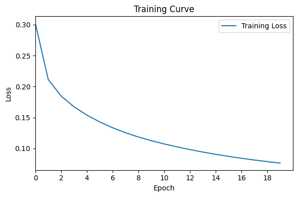

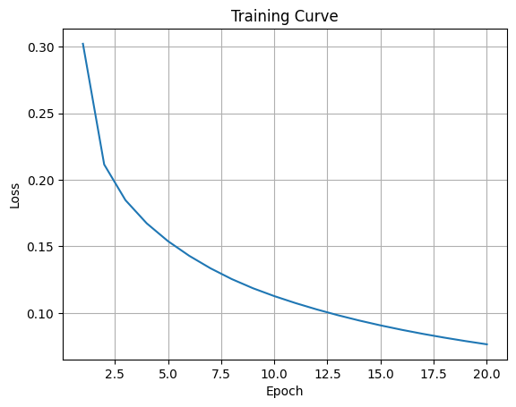

```python
# =================== YOUR CODE STARTS HERE ==================

# Write code to plot the learning curve.

#using train_losses variable calculated previously

plt.plot(range(1, num_epochs + 1), train_losses)
plt.title('Training Curve')
plt.xlabel('Epoch')
plt.ylabel('Loss')
plt.grid(True)
plt.show()








# =================== YOUR CODE ENDS HERE ==================
```

### Question 1.6 -- [5pt]

Interpret the obtained training curve. What is this graph demonstraiting? Does it look correct? Remember to define correct!

(Again, note that you do not have to provide any code here in this question. A brief textual explanation is absolutely sufficient.)

```python
# =================== YOUR ANSWER STARTS HERE ==================

'''
The training curve, as shown by the provided train_losses, represents the
change in the average training loss over the course of training epochs.

Interpretation:
The training curve is decreasing, indicating that the model is learning and
improving its performance on the training data over epochs.
The initial high loss suggests that the model's predictions were initially
far from the ground truth labels.
As training progresses, the loss decreases, suggesting that the model is
adjusting its parameters to better fit the training data.

Correctness:
In the context of training a neural network, a correct learning curve generally
exhibits a decreasing trend, as the goal is to minimize the loss. In this case,
the decreasing trend suggests that the model is learning effectively.


'''



# ==================== YOUR ANSWER ENDS HERE ===================
```

```python
# Computing accuracy on the test set
def compute_accuracy(dataset):
    correct = 0
    total = len(dataset)
    for (image, label) in dataset:
        prob = torch.sigmoid(pigeon(img_to_tensor(image)))
        if (prob < 0.5 and label < 3) or (prob >= 0.5 and label >= 3):
            correct += 1
    return correct / total

train_accuracy = 1 - compute_accuracy(mnist_train)
test_accuracy = 1 - compute_accuracy(mnist_val)

print("Training Accuracy:", train_accuracy)
print("Test Accuracy:", test_accuracy)
```

```
Training Accuracy: 0.981
Test Accuracy: 0.885
```

### Question 1.7 -- [5pt]

Report the Training and Test accuracy of this model. Interpret and explain these results. How do you think we can we improve them? (Textual explanation is required.)

```python
# =================== YOUR ANSWER STARTS HERE ==================

'''
The reported training accuracy is approximately 98.1%, and the test accuracy
is approximately 88.5%.

Training Accuracy (98.1%):
The high training accuracy suggests that the model is performing well on
the training data. It correctly classifies around 98.1% of the training samples.
A very high training accuracy might indicate that the model has
learned the training data well, but it's essential to assess its
generalization to unseen data.

Test Accuracy (88.5%):
The test accuracy, while reasonably high, is noticeably lower than the
training accuracy. This suggests a potential performance gap between the
training and test datasets, indicating some degree of overfitting.
Overfitting occurs when the model performs well on the training data
but struggles to generalize to new, unseen data.

Potential Improvements:

Regularization: Implement regularization techniques (e.g., dropout)
to prevent overfitting and improve generalization.

Hyperparameter Tuning: Adjust hyperparameters like learning rate, batch size,
or model architecture to find a better balance between training
and test performance.

Validation Set: Introduce a validation set during training to monitor
performance and adjust the model accordingly.

Interpretation:
The model may be too complex, capturing noise in the training data,
leading to overfitting.

The gap between training and test accuracy suggests a need for
regularization or adjustments to improve the model's generalization.

'''


# ==================== YOUR ANSWER ENDS HERE ===================
```

Now, let's delve into 2-layer networks!

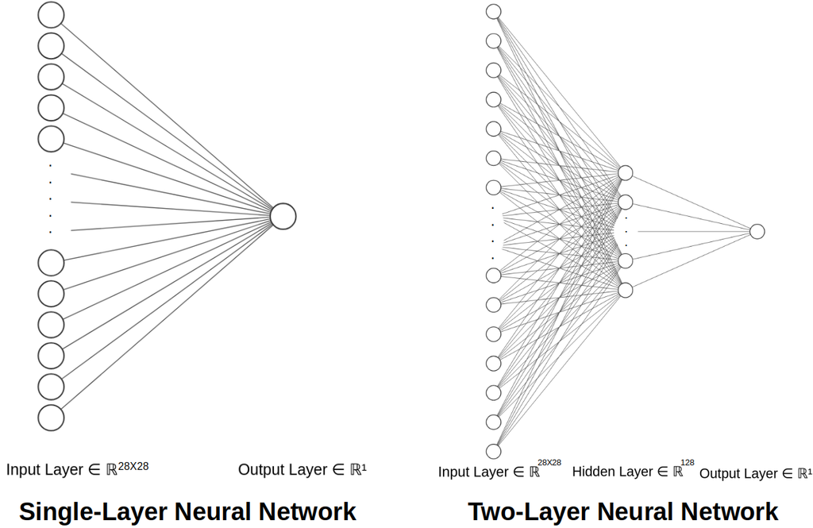

http://alexlenail.me/NN-SVG/index.html was used to generate the above image. Check it out! It might be helpful.

### Question 1.8 -- [3pt]

Please fill in the blanks based on the above image.

```python
# define a 2-layer artificial neural network
class Pigeon2(nn.Module):
    def __init__(self):
        super(Pigeon2, self).__init__()
        # =================== YOUR CODE STARTS HERE ==================
        self.layer1 = nn.Linear( 28 * 28   , 128   ) # Fill in the number of input and output nodes
        self.layer2 = nn.Linear( 128   ,  1  ) # Fill in the number of input and output nodes
        # ==================== YOUR CODE ENDS HERE ===================

    def forward(self, img):
        flattened = img.view(-1, 28 * 28)
        activation1 = self.layer1(flattened)
        activation1 = F.relu(activation1)
        activation2 = self.layer2(activation1)
        return activation2

pigeon2 = Pigeon2()
```

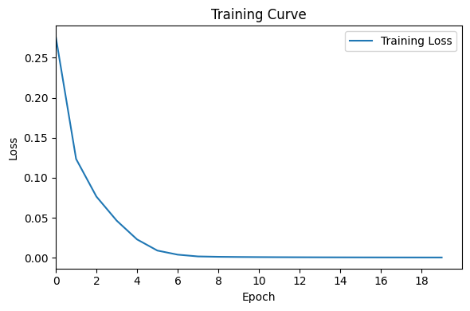

```python
# Training settings
criterion = nn.BCEWithLogitsLoss()
optimizer = optim.SGD(pigeon2.parameters(), lr=0.005, momentum=0.9)
num_epochs = 20  # Number of training epochs

# Training loop with progress bar
train_losses = []
for epoch in tqdm(range(num_epochs), desc='Training Progress'):
    epoch_loss = 0.0
    for (image, label) in mnist_train:
        actual = torch.tensor(label < 3).reshape([1, 1]).type(torch.FloatTensor)
        out = pigeon2(img_to_tensor(image))
        loss = criterion(out, actual)
        loss.backward()
        optimizer.step()
        optimizer.zero_grad()
        epoch_loss += loss.item()
    train_losses.append(epoch_loss / len(mnist_train))

# Plotting the training curve
plt.figure(figsize=(6, 4))
plt.plot(range(num_epochs), train_losses, label='Training Loss')
plt.xlabel('Epoch')
plt.ylabel('Loss')
plt.title('Training Curve')
plt.legend()
plt.grid(False)
plt.xticks(range(0,num_epochs, 2))  # Integer values for epochs on X axis
plt.xlim(0, num_epochs)  # Set the x-axis limits
plt.tight_layout()
plt.show()
```

```python
# Computing accuracy on the test set
def compute_accuracy(dataset):
    correct = 0
    total = len(dataset)
    for (image, label) in dataset:
        prob = torch.sigmoid(pigeon2(img_to_tensor(image)))
        if (prob < 0.5 and label < 3) or (prob >= 0.5 and label >= 3):
            correct += 1
    return correct / total

train_accuracy = 1 - compute_accuracy(mnist_train)
test_accuracy = 1 - compute_accuracy(mnist_val)

print("Training Accuracy:", train_accuracy)
print("Test Accuracy:", test_accuracy)
```

```
Training Accuracy: 1.0
Test Accuracy: 0.9410000000000001
```

### Question 1.9 -- [5pt]

Report the Training and Test accuracy of this new model. Compare these results to the ones you obtained from single-layer model. (Textual explanation is required.)

```python
# =================== YOUR ANSWER STARTS HERE ==================

'''

The training accuracy of the new 2-layer model is reported as 1.0 (100%),
while the test accuracy is approximately 94.1%. Comparison:

Training Accuracy:
The training accuracy of 1.0 indicates that the 2-layer model has achieved
perfect accuracy on the training set. Every sample in the training data
is correctly classified.

Test Accuracy:
The test accuracy of approximately 94.1% is noticeably higher than
the test accuracy of the single-layer model (88.5%).

Comparison with Single-layer Model:
The 2-layer model exhibits superior performance on both the training and test
sets compared to the single-layer model.

The increased capacity of the 2-layer model allows it to capture more
complex patterns in the data, resulting in improved generalization
to unseen samples.

Observations:
Achieving perfect training accuracy might indicate potential overfitting to the
training data. Further evaluation on a validation set or additional
regularization techniques may be necessary.

The higher test accuracy suggests that the added complexity of the 2-layer
model is beneficial for capturing intricate patterns in the data.

In conclusion, the 2-layer model outperforms the single-layer model in
terms of accuracy, emphasizing the impact of increased model complexity.
However, further investigation and fine-tuning are recommended to address
potential overfitting and ensure robust generalization.

'''


# ==================== YOUR ANSWER ENDS HERE ===================
```